# Mental Health Sentiment Analysis

Class Exercise 2 - Data Mining in R

Camila and Jessica

2024-05-03

## Research Question

#### Does the sentiment of mental health articles vary significantly between different authors?

### Hypothesis

We hypothesize that there will be a significant difference in sentiment scores among authors contributing to mental health articles.

### Data Collection

We collected articles related to mental health using the Guardian API, extracting fields such as title, body, and author.

### Data Prep

The text data was processed to lowercase, remove punctuation and digits.

### Tokenization

The text was tokenized into individual words, and stop words were removed. We obtained after the first process 3.235 words. Out of the words collected we plot the word frequency per author, the results are below:

**The most frequent words per author:**

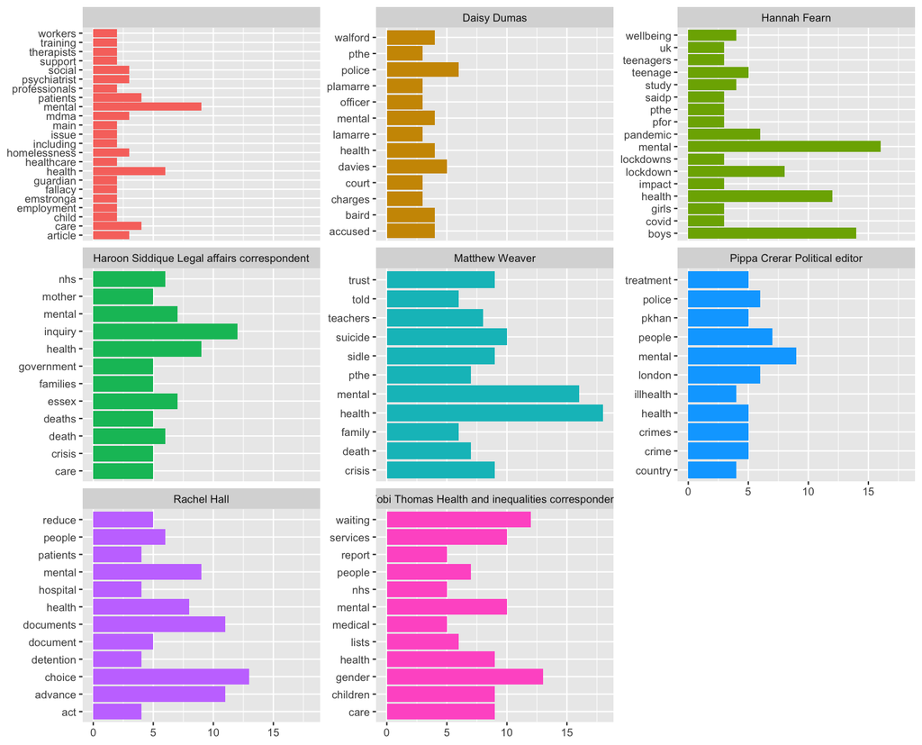

**The word most frequent per author:**

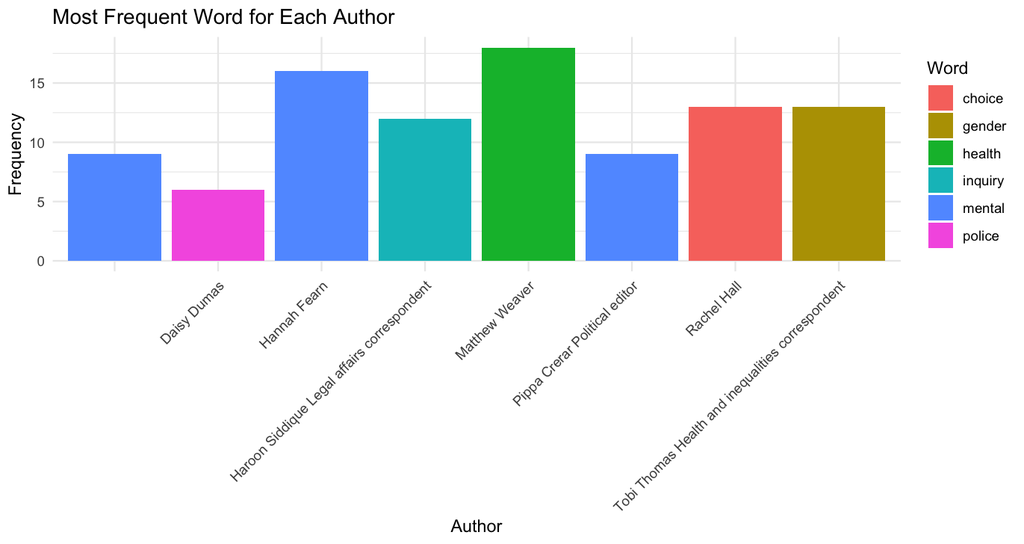

**We also use Wordcloud to provide us a image of the most frequent words overall:**

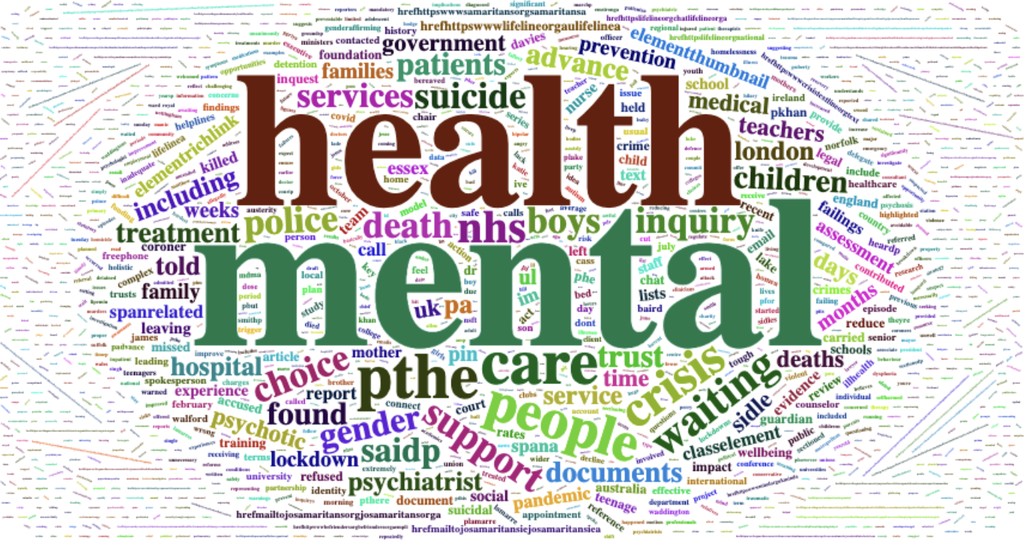

### Sentiment Analysis

**We plot the results on histogram:**

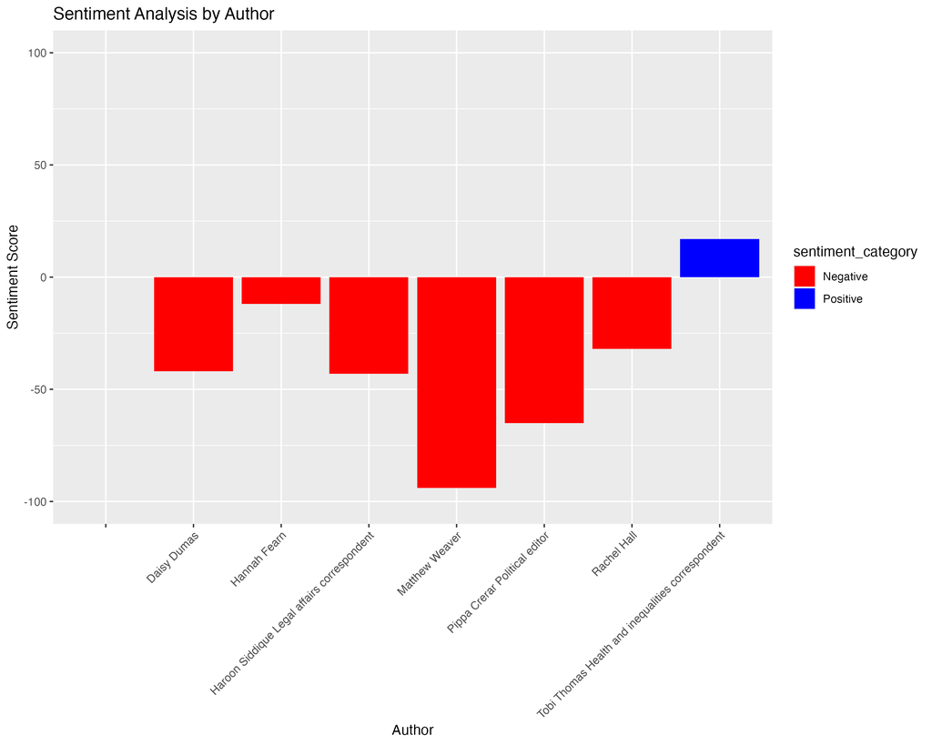